# L’Ultimo Teorema di Fermat e la Dimostrazione di Andrew Wiles

Un viaggio attraverso curve ellittiche, forme modulari e 357 anni di mistero

Autore/Autrice

Alberto Oliva

E-mail

eng.aoliva@gmail.com

Data di Pubblicazione

15 aprile 2026

Sommario

Questo documento illustra, in linguaggio accessibile ma rigoroso, la storia e la struttura della dimostrazione di Andrew Wiles dell’Ultimo Teorema di Fermat (1995). Partendo dal contesto storico, esploriamo i tre pilastri della dimostrazione — curve ellittiche, forme modulari e la congettura di Taniyama-Shimura-Weil — e spieghiamo come Wiles abbia costruito un ponte tra due mondi matematici distanti per chiudere un problema aperto da 357 anni.

# 1 Contesto Storico

## 1.1 Il margine di un libro e 357 anni di silenzio

Nel **1637**, il matematico francese Pierre de Fermat stava leggendo l’*Arithmetica* di Diofanto, un testo matematico greco del III secolo d.C. A margine di una pagina, scrisse una nota che avrebbe ossessionato i matematici per quasi quattro secoli:

**NotaLa Nota di Fermat (1637)**

> *“È impossibile separare un cubo in due cubi, o una potenza quarta in due potenze quarte, o in generale qualsiasi potenza superiore al quadrato in due potenze dello stesso esponente. Ho scoperto una dimostrazione veramente meravigliosa di questa proposizione, ma questo margine è troppo stretto per contenerla.”*

In simboli: l’equazione $x^n + y^n = z^n$ **non ha soluzioni intere positive** per $n > 2$.

Mentre per $n = 2$ abbiamo infinite soluzioni (le **terne pitagoriche**: $3^2 + 4^2 = 5^2$, $5^2 + 12^2 = 13^2$, ecc.), Fermat affermava che alzare l’esponente a 3, 4, 5, … rende il problema impossibile.

## 1.2 Linea del tempo

**Codice**

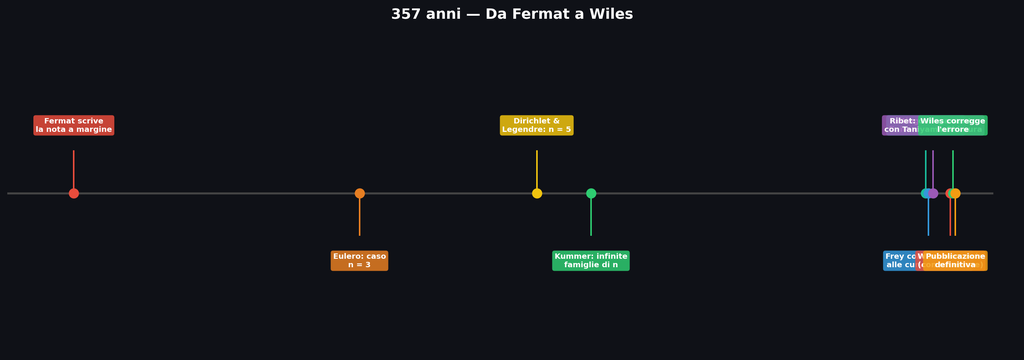

Figura 1: Linea del tempo: dalla sfida di Fermat alla dimostrazione di Wiles

```python
import matplotlib.pyplot as plt
import matplotlib.patches as mpatches
import numpy as np

fig, ax = plt.subplots(figsize=(14, 5))
fig.patch.set_facecolor('#0f1117')
ax.set_facecolor('#0f1117')

events = [
    (1637, "Fermat scrive\nla nota a margine", "#e74c3c"),
    (1753, "Eulero: caso\nn = 3", "#e67e22"),
    (1825, "Dirichlet &\nLegendre: n = 5", "#f1c40f"),
    (1847, "Kummer: infinite\nfamiglie di n", "#2ecc71"),
    (1983, "Faltings: numero\nfinito di soluzioni", "#1abc9c"),
    (1984, "Frey collega Fermat\nalle curve ellittiche", "#3498db"),
    (1986, "Ribet: collegamento\ncon Taniyama-Shimura", "#9b59b6"),
    (1993, "Wiles annuncia\n(con un errore)", "#e74c3c"),
    (1994, "Wiles corregge\nl'errore", "#2ecc71"),
    (1995, "Pubblicazione\ndefinitiva", "#f39c12"),
]

years = [e[0] for e in events]
y_min, y_max = 1600, 2010

# Linea principale
ax.plot([y_min, y_max], [0, 0], color='#444', linewidth=2, zorder=1)

for i, (year, label, color) in enumerate(events):
    y_offset = 0.3 if i % 2 == 0 else -0.3
    ax.plot([year, year], [0, y_offset * 0.7], color=color, linewidth=1.5, zorder=2)
    ax.scatter([year], [0], color=color, s=80, zorder=3)
    ax.text(year, y_offset, label, ha='center', va='bottom' if y_offset > 0 else 'top',
            fontsize=7.5, color='white', fontweight='bold',
            bbox=dict(boxstyle='round,pad=0.3', facecolor=color, alpha=0.85, edgecolor='none'))

ax.set_xlim(1610, 2020)
ax.set_ylim(-0.8, 0.8)
ax.axis('off')
ax.set_title("357 anni — Da Fermat a Wiles", color='white', fontsize=14, fontweight='bold', pad=15)

plt.tight_layout()
plt.savefig("timeline.png", dpi=150, bbox_inches='tight', facecolor='#0f1117')
plt.show()
```

**ImportantePerché è così difficile?**

A differenza di molti problemi famosi, l’Ultimo Teorema di Fermat è **facile da enunciare** ma richiede strumenti matematici del XX secolo per essere dimostrato. La “dimostrazione meravigliosa” di Fermat — se mai esistette — era quasi certamente errata.

# 2 I Tre Pilastri della Dimostrazione

La dimostrazione di Wiles si regge su tre strutture matematiche fondamentali, tenute insieme dalla **Congettura di Taniyama-Shimura-Weil**. Prima di capire come funziona il ponte, dobbiamo capire le due rive.

## 2.1 Pilastro I — Le Curve Ellittiche

### 2.1.1 Cosa sono

Una **curva ellittica** è il luogo dei punti $(x, y)$ nel piano che soddisfano:

$$y^2 = x^3 + ax + b$$

con $4a^3 + 27b^2 \neq 0$ (condizione di non-singolarità).

**Codice**

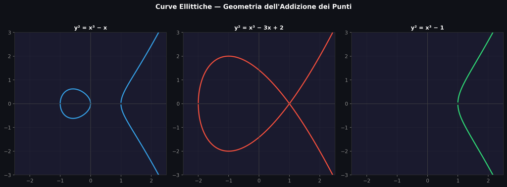

```python
import matplotlib.pyplot as plt
import numpy as np

fig, axes = plt.subplots(1, 3, figsize=(14, 5))
fig.patch.set_facecolor('#0f1117')

curves = [
    (-1, 0,  "y² = x³ − x",       "#3498db"),
    (-3, 2,  "y² = x³ − 3x + 2",  "#e74c3c"),
    ( 0, -1, "y² = x³ − 1",       "#2ecc71"),
]

for ax, (a, b, title, color) in zip(axes, curves):
    ax.set_facecolor('#1a1a2e')

    x_vals = np.linspace(-2.5, 2.5, 2000)
    rhs = x_vals**3 + a * x_vals + b
    mask = rhs >= 0

    y_pos =  np.sqrt(np.where(mask, rhs, np.nan))
    y_neg = -np.sqrt(np.where(mask, rhs, np.nan))

    ax.plot(x_vals, y_pos, color=color, linewidth=2.2)
    ax.plot(x_vals, y_neg, color=color, linewidth=2.2)

    # Addizione geometrica: P + Q
    try:
        # Trova due punti sulla curva
        x_p = -1.0
        rhs_p = x_p**3 + a*x_p + b
        if rhs_p > 0:
            y_p = np.sqrt(rhs_p)
            x_q = 1.0
            rhs_q = x_q**3 + a*x_q + b
            if rhs_q > 0:
                y_q = np.sqrt(rhs_q)
                # Retta per P e Q
                m = (y_q - y_p) / (x_q - x_p) if x_q != x_p else None
                if m is not None:
                    x_r = m**2 - x_p - x_q
                    rhs_r = x_r**3 + a*x_r + b
                    if rhs_r >= 0:
                        y_r = -np.sqrt(rhs_r)
                        # Disegna retta
                        xl = np.linspace(min(x_p, x_q) - 0.5, max(x_p, x_q) + 0.5, 100)
                        yl = m * (xl - x_p) + y_p
                        ax.plot(xl, yl, '--', color='#f1c40f', linewidth=1, alpha=0.7)
                        # Punti
                        ax.scatter([x_p, x_q, x_r], [y_p, y_q, y_r],
                                   color=['#f1c40f','#f1c40f','#e74c3c'], s=60, zorder=5)
                        ax.annotate('P', (x_p, y_p), textcoords="offset points",
                                    xytext=(-15, 5), color='#f1c40f', fontsize=9, fontweight='bold')
                        ax.annotate('Q', (x_q, y_q), textcoords="offset points",
                                    xytext=(5, 5), color='#f1c40f', fontsize=9, fontweight='bold')
                        ax.annotate('P+Q', (x_r, y_r), textcoords="offset points",
                                    xytext=(5, -15), color='#e74c3c', fontsize=9, fontweight='bold')
    except Exception:
        pass

    ax.axhline(0, color='#444', linewidth=0.8)
    ax.axvline(0, color='#444', linewidth=0.8)
    ax.set_xlim(-2.5, 2.5)
    ax.set_ylim(-3, 3)
    ax.set_title(title, color='white', fontsize=11, fontweight='bold')
    ax.tick_params(colors='#888')
    for spine in ax.spines.values():
        spine.set_edgecolor('#333')
    ax.grid(True, alpha=0.15, color='#555')

fig.suptitle("Curve Ellittiche — Geometria dell'Addizione dei Punti",
             color='white', fontsize=13, fontweight='bold', y=1.02)
plt.tight_layout()
plt.savefig("elliptic_curves.png", dpi=150, bbox_inches='tight', facecolor='#0f1117')
plt.show()
```

**NotaNota Terminologica**

Il nome “ellittica” è storico, non descrittivo: queste curve emergono nel calcolo della lunghezza degli archi delle ellissi. Non hanno la forma di un’ellisse.

### 2.1.2 La firma aritmetica

Quando si studiano le curve ellittiche su campi finiti $\mathbb{F}_p$, si definisce:

$$a_p = p + 1 - \#E(\mathbb{F}_p)$$

La sequenza $\{a_p\}$ è la **firma aritmetica** della curva.

**Codice**

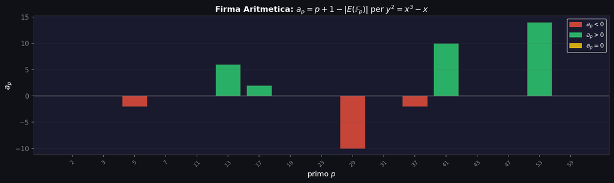

Figura 3: Firma aritmetica della curva y² = x³ − x: coefficienti a_p per i primi p

```python
import matplotlib.pyplot as plt
import numpy as np

def count_points_mod_p(a, b, p):
    """Conta i punti di y^2 = x^3 + ax + b su F_p (incluso punto all'infinito)."""
    count = 1  # punto all'infinito
    for x in range(p):
        rhs = (x**3 + a*x + b) % p
        for y in range(p):
            if (y*y) % p == rhs:
                count += 1
    return count

def sieve_primes(n):
    sieve = [True] * (n+1)
    sieve[0] = sieve[1] = False
    for i in range(2, int(n**0.5)+1):
        if sieve[i]:
            for j in range(i*i, n+1, i):
                sieve[j] = False
    return [i for i in range(2, n+1) if sieve[i]]

primes = sieve_primes(60)
a_vals = [p + 1 - count_points_mod_p(-1, 0, p) for p in primes]

fig, ax = plt.subplots(figsize=(13, 4))
fig.patch.set_facecolor('#0f1117')
ax.set_facecolor('#1a1a2e')

colors = ['#e74c3c' if v < 0 else '#2ecc71' if v > 0 else '#f1c40f' for v in a_vals]
bars = ax.bar(range(len(primes)), a_vals, color=colors, alpha=0.85, edgecolor='#333', linewidth=0.5)

ax.axhline(0, color='#888', linewidth=1)
ax.set_xticks(range(len(primes)))
ax.set_xticklabels([str(p) for p in primes], fontsize=8, color='#aaa', rotation=45)
ax.set_ylabel('$a_p$', color='white', fontsize=12)
ax.set_xlabel('primo $p$', color='white', fontsize=11)
ax.set_title(r'Firma Aritmetica: $a_p = p + 1 - |E(\mathbb{F}_p)| \;\mathrm{per}\; y^2 = x^3 - x$',
             color='white', fontsize=12, fontweight='bold')
ax.tick_params(colors='#888')
for spine in ax.spines.values():
    spine.set_edgecolor('#333')
ax.grid(axis='y', alpha=0.15, color='#555')

neg_patch = mpatches.Patch(color='#e74c3c', alpha=0.85, label='$a_p < 0$')
pos_patch = mpatches.Patch(color='#2ecc71', alpha=0.85, label='$a_p > 0$')
zer_patch = mpatches.Patch(color='#f1c40f', alpha=0.85, label='$a_p = 0$')
ax.legend(handles=[neg_patch, pos_patch, zer_patch], facecolor='#1a1a2e',
          labelcolor='white', fontsize=9, loc='upper right')

plt.tight_layout()
plt.savefig("signature.png", dpi=150, bbox_inches='tight', facecolor='#0f1117')
plt.show()
```

## 2.2 Pilastro II — Le Forme Modulari

### 2.2.1 Simmetria nel semipiano complesso

Le **forme modulari** vivono nel semipiano superiore $\mathbb{H} = \{ z \in \mathbb{C} : \text{Im}(z) > 0 \}$ e si trasformano sotto $\text{SL}_2(\mathbb{Z})$:

$$f\!\left(\frac{az + b}{cz + d}\right) = (cz + d)^k \, f(z)$$

**Codice**

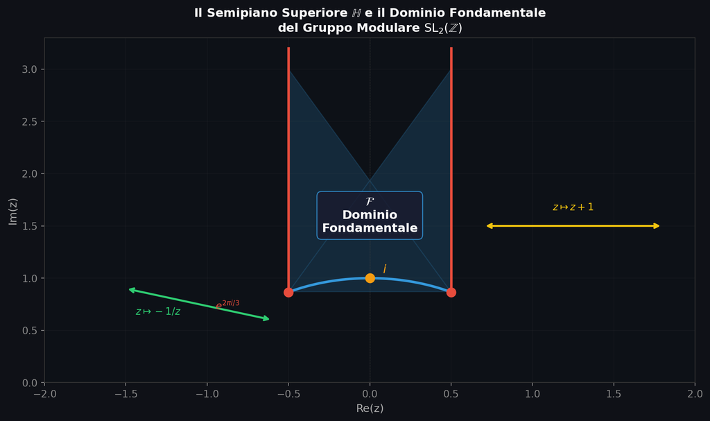

Figura 4: Il dominio fondamentale del gruppo modulare — regione di simmetria delle forme modulari

```python
import matplotlib.pyplot as plt
import matplotlib.patches as mpatches
from matplotlib.patches import Arc, FancyArrowPatch
import numpy as np

fig, ax = plt.subplots(figsize=(10, 6))
fig.patch.set_facecolor('#0f1117')
ax.set_facecolor('#0d1117')

# Dominio fondamentale
theta = np.linspace(np.pi/3, 2*np.pi/3, 300)
x_arc = np.cos(theta)
y_arc = np.sin(theta)

# Riempimento dominio fondamentale
theta_fill = np.linspace(np.pi/3, 2*np.pi/3, 300)
x_fill = np.concatenate([[-0.5], np.cos(theta_fill), [0.5, 0.5, -0.5]])
y_fill = np.concatenate([[3.0], np.sin(theta_fill), [3.0, 0.87, 0.87]])
ax.fill(x_fill, y_fill, alpha=0.18, color='#3498db')
ax.plot(np.cos(theta), np.sin(theta), color='#3498db', linewidth=2.5, label='Arco unitario')

# Linee verticali
ax.plot([-0.5, -0.5], [np.sqrt(3)/2, 3.2], color='#e74c3c', linewidth=2.5)
ax.plot([ 0.5,  0.5], [np.sqrt(3)/2, 3.2], color='#e74c3c', linewidth=2.5, label='Linee Re(z) = ±½')

# Frecce simmetria
ax.annotate('', xy=(1.8, 1.5), xytext=(0.7, 1.5),
            arrowprops=dict(arrowstyle='<->', color='#f1c40f', lw=2))
ax.text(1.25, 1.65, '$z \\mapsto z+1$', color='#f1c40f', fontsize=10, ha='center', fontweight='bold')

ax.annotate('', xy=(-1.5, 0.9), xytext=(-0.6, 0.6),
            arrowprops=dict(arrowstyle='<->', color='#2ecc71', lw=2))
ax.text(-1.3, 0.65, '$z \\mapsto -1/z$', color='#2ecc71', fontsize=10, ha='center', fontweight='bold')

# Dominio fondamentale label
ax.text(0, 1.6, '$\\mathcal{F}$\nDominio\nFondamentale', color='white', fontsize=12,
        ha='center', va='center', fontweight='bold',
        bbox=dict(boxstyle='round,pad=0.4', facecolor='#1a1a2e', alpha=0.8, edgecolor='#3498db'))

# Punti speciali
ax.scatter([0], [1], color='#f39c12', s=80, zorder=5)
ax.annotate('$i$', (0, 1), xytext=(0.08, 1.05), color='#f39c12', fontsize=12, fontweight='bold')

ax.scatter([-0.5, 0.5], [np.sqrt(3)/2]*2, color='#e74c3c', s=80, zorder=5)
ax.annotate('$e^{2\\pi i/3}$', (-0.5, np.sqrt(3)/2), xytext=(-0.95, 0.7),
            color='#e74c3c', fontsize=10, fontweight='bold')

ax.axhline(0, color='#444', linewidth=0.8)
ax.axvline(0, color='#444', linewidth=0.5, linestyle='--', alpha=0.5)

ax.set_xlim(-2, 2)
ax.set_ylim(0, 3.3)
ax.set_xlabel('Re(z)', color='#aaa', fontsize=11)
ax.set_ylabel('Im(z)', color='#aaa', fontsize=11)
ax.set_title('Il Semipiano Superiore $\\mathbb{H}$ e il Dominio Fondamentale\ndel Gruppo Modulare $\\text{SL}_2(\\mathbb{Z})$',
             color='white', fontsize=12, fontweight='bold')
ax.tick_params(colors='#888')
for spine in ax.spines.values():
    spine.set_edgecolor('#333')
ax.grid(True, alpha=0.1, color='#555')

plt.tight_layout()
plt.savefig("modular_domain.png", dpi=150, bbox_inches='tight', facecolor='#0f1117')
plt.show()
```

Ogni forma modulare ha un’espansione di Fourier:
$$f(z) = \sum_{n=0}^{\infty} a_n \, q^n, \quad q = e^{2\pi i z}$$

La sequenza $\{a_n\}$ è la sua **firma numerica** — la identifica completamente.

## 2.3 Pilastro III — La Congettura di Taniyama-Shimura-Weil

**Codice**

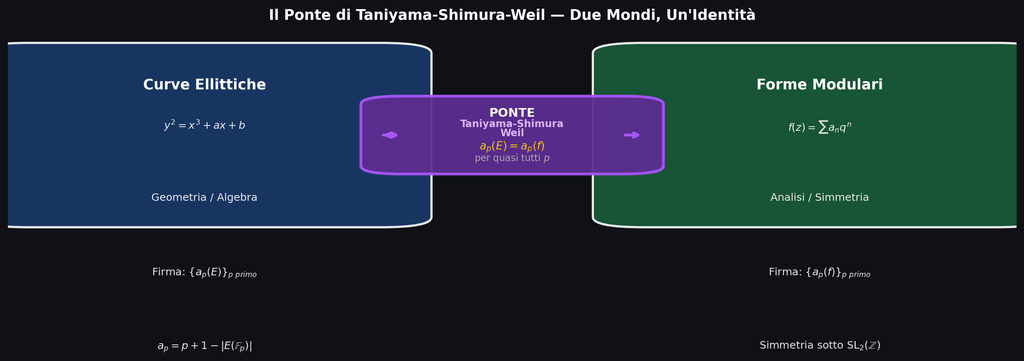

Figura 5: Il ponte di Taniyama-Shimura-Weil tra i due mondi matematici

```python
import matplotlib.pyplot as plt
import matplotlib.patches as mpatches
from matplotlib.patches import FancyBboxPatch, FancyArrowPatch
import numpy as np

fig, ax = plt.subplots(figsize=(13, 5.5))
fig.patch.set_facecolor('#0f1117')
ax.set_facecolor('#0f1117')
ax.axis('off')

def draw_box(ax, x, y, w, h, title, lines, color, text_color='white'):
    box = FancyBboxPatch((x, y), w, h, boxstyle="round,pad=0.05",
                          facecolor=color, edgecolor='white', linewidth=2, alpha=0.9)
    ax.add_patch(box)
    ax.text(x + w/2, y + h - 0.12, title, ha='center', va='top',
            fontsize=13, fontweight='bold', color=text_color)
    for i, line in enumerate(lines):
        ax.text(x + w/2, y + h - 0.32 - i*0.18, line, ha='center', va='top',
                fontsize=9.5, color=text_color, alpha=0.9)

# Box sinistra — Curve Ellittiche
draw_box(ax, 0.02, 0.1, 0.35, 0.8,
         "Curve Ellittiche",
         ["$y^2 = x^3 + ax + b$", "", "Geometria / Algebra", "",
          "Firma: $\\{a_p(E)\\}_{p\\ primo}$", "", "$a_p = p+1-|E(\\mathbb{F}_p)|$"],
         '#1a3a6b')

# Box destra — Forme Modulari
draw_box(ax, 0.63, 0.1, 0.35, 0.8,
         "Forme Modulari",
         ["$f(z) = \\sum a_n q^n$", "", "Analisi / Simmetria", "",
          "Firma: $\\{a_p(f)\\}_{p\\ primo}$", "", "Simmetria sotto $\\text{SL}_2(\\mathbb{Z})$"],
         '#1a5c3a')

# Ponte centrale
bridge = FancyBboxPatch((0.39, 0.35), 0.22, 0.3, boxstyle="round,pad=0.04",
                         facecolor='#5c2d91', edgecolor='#a855f7', linewidth=2.5, alpha=0.95)
ax.add_patch(bridge)
ax.text(0.50, 0.635, "PONTE", ha='center', va='top', fontsize=11,
        fontweight='bold', color='white')
ax.text(0.50, 0.58, "Taniyama-Shimura", ha='center', va='top', fontsize=9,
        color='#d8b4fe', fontweight='bold')
ax.text(0.50, 0.535, "Weil", ha='center', va='top', fontsize=9,
        color='#d8b4fe', fontweight='bold')
ax.text(0.50, 0.475, "$a_p(E) = a_p(f)$", ha='center', va='top', fontsize=10,
        color='#f1c40f', fontweight='bold')
ax.text(0.50, 0.415, "per quasi tutti $p$", ha='center', va='top', fontsize=8.5,
        color='#aaa')

# Frecce
ax.annotate('', xy=(0.39, 0.5), xytext=(0.37, 0.5),
            arrowprops=dict(arrowstyle='->', color='#a855f7', lw=2.5))
ax.annotate('', xy=(0.63, 0.5), xytext=(0.61, 0.5),
            arrowprops=dict(arrowstyle='->', color='#a855f7', lw=2.5))

# Frecce dal box sinistro al ponte e dal ponte al box destro
ax.annotate('', xy=(0.39, 0.5), xytext=(0.37, 0.5),
            arrowprops=dict(arrowstyle='<->', color='#a855f7', lw=2.5))

ax.set_xlim(0, 1)
ax.set_ylim(0, 1)
ax.set_title("Il Ponte di Taniyama-Shimura-Weil — Due Mondi, Un'Identità",
             color='white', fontsize=13, fontweight='bold', pad=12)

plt.tight_layout()
plt.savefig("bridge.png", dpi=150, bbox_inches='tight', facecolor='#0f1117')
plt.show()
```

**ImportanteCongettura di Taniyama-Shimura-Weil (1955/1967)**

> Ogni curva ellittica definita sui razionali è **modulare**: esiste una forma modulare di peso 2 la cui sequenza di coefficienti di Fourier coincide con la firma aritmetica della curva.

$$\forall E/\mathbb{Q} \;\exists\; f \text{ modulare} : a_p(E) = a_p(f) \quad \text{per quasi tutti i primi } p$$

# 3 Il Collegamento con Fermat: La Curva di Frey

## 3.1 L’idea di Gerhard Frey (1984)

**AvvisoL’Ipotesi di Frey**

Supponiamo per assurdo che esista una soluzione intera:
$$a^p + b^p = c^p, \quad p \geq 5 \text{ primo}, \quad abc \neq 0$$
Allora si può costruire la **curva ellittica di Frey**:
$$E_{\text{Frey}}: \quad y^2 = x(x - a^p)(x + b^p)$$
Questa curva avrebbe proprietà numeriche così irregolari da risultare **incompatibile** con l’essere modulare.

## 3.2 La catena logica completa

**Codice**

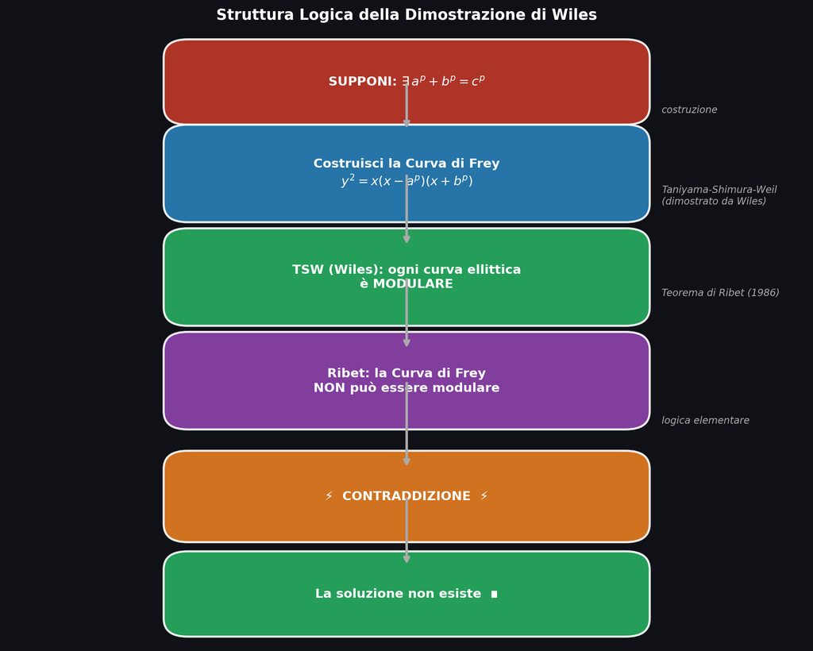

Figura 6: La catena logica della dimostrazione — dall’ipotesi alla contraddizione

```python
import matplotlib.pyplot as plt
import matplotlib.patches as mpatches
from matplotlib.patches import FancyBboxPatch, FancyArrowPatch
import numpy as np

fig, ax = plt.subplots(figsize=(10, 8))
fig.patch.set_facecolor('#0f1117')
ax.set_facecolor('#0f1117')
ax.axis('off')

steps = [
    (0.5, 0.92, "SUPPONI: $\\exists\\, a^p + b^p = c^p$", '#c0392b', 0.55, 0.08),
    (0.5, 0.77, "Costruisci la Curva di Frey\n$y^2 = x(x-a^p)(x+b^p)$", '#2980b9', 0.55, 0.10),
    (0.5, 0.60, "TSW (Wiles): ogni curva ellittica\nè MODULARE", '#27ae60', 0.55, 0.10),
    (0.5, 0.43, "Ribet: la Curva di Frey\nNON può essere modulare", '#8e44ad', 0.55, 0.10),
    (0.5, 0.24, "⚡  CONTRADDIZIONE  ⚡", '#e67e22', 0.55, 0.09),
    (0.5, 0.08, "La soluzione non esiste  ∎", '#27ae60', 0.55, 0.08),
]

for x, y, text, color, w, h in steps:
    box = FancyBboxPatch((x - w/2, y - h/2), w, h,
                          boxstyle="round,pad=0.03",
                          facecolor=color, edgecolor='white', linewidth=1.8, alpha=0.9)
    ax.add_patch(box)
    ax.text(x, y, text, ha='center', va='center',
            fontsize=11, fontweight='bold', color='white')

arrows = [(0.92, 0.84), (0.77, 0.65), (0.60, 0.48), (0.43, 0.285), (0.24, 0.125)]
for y_start, y_end in arrows:
    ax.annotate('', xy=(0.5, y_end), xytext=(0.5, y_start),
                arrowprops=dict(arrowstyle='->', color='#aaa', lw=2.2))

ax.text(0.82, 0.87, 'costruzione', color='#aaa', fontsize=8.5, ha='left', style='italic')
ax.text(0.82, 0.72, 'Taniyama-Shimura-Weil\n(dimostrato da Wiles)', color='#aaa', fontsize=8.5, ha='left', style='italic')
ax.text(0.82, 0.57, 'Teorema di Ribet (1986)', color='#aaa', fontsize=8.5, ha='left', style='italic')
ax.text(0.82, 0.36, 'logica elementare', color='#aaa', fontsize=8.5, ha='left', style='italic')

ax.set_xlim(0, 1)
ax.set_ylim(0, 1)
ax.set_title("Struttura Logica della Dimostrazione di Wiles",
             color='white', fontsize=13, fontweight='bold', pad=12)

plt.tight_layout()
plt.savefig("logic_chain.png", dpi=150, bbox_inches='tight', facecolor='#0f1117')
plt.show()
```

# 4 La Dimostrazione: Lo Strumento Tecnico

## 4.1 Le Rappresentazioni di Galois

Ad ogni curva ellittica $E$ e primo $\ell$ si associa una rappresentazione:

$$\rho_{E,\ell}: \text{Gal}(\overline{\mathbb{Q}}/\mathbb{Q}) \longrightarrow GL_2(\mathbb{Z}_\ell)$$

che codifica come i punti di $\ell$-torsione di $E$ si trasformano sotto l’azione del gruppo di Galois assoluto.

## 4.2 La Strategia di Deformazione di Wiles

**Codice**

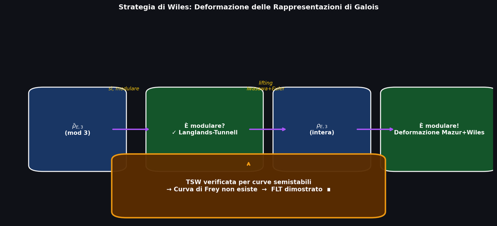

Figura 7: Schema della strategia di deformazione usata da Wiles

```python
import matplotlib.pyplot as plt
from matplotlib.patches import FancyBboxPatch
import matplotlib.patches as mpatches

fig, ax = plt.subplots(figsize=(12, 5.5))
fig.patch.set_facecolor('#0f1117')
ax.set_facecolor('#0f1117')
ax.axis('off')

nodes = [
    (0.08, 0.45, "$\\bar{\\rho}_{E,3}$\n(mod 3)", '#1a3a6b', 0.14, 0.35),
    (0.32, 0.45, "È modulare?\n✓ Langlands-Tunnell", '#155c2c', 0.18, 0.35),
    (0.58, 0.45, "$\\rho_{E,3}$\n(intera)", '#1a3a6b', 0.14, 0.35),
    (0.80, 0.45, "È modulare!\nDeformazione Mazur+Wiles", '#155c2c', 0.18, 0.35),
]

for x, y, text, color, w, h in nodes:
    box = FancyBboxPatch((x, y - h/2), w, h, boxstyle="round,pad=0.03",
                          facecolor=color, edgecolor='white', linewidth=1.8, alpha=0.92)
    ax.add_patch(box)
    ax.text(x + w/2, y, text, ha='center', va='center',
            fontsize=10, fontweight='bold', color='white')

# Frecce orizzontali
arrow_positions = [(0.22, 0.45), (0.50, 0.45), (0.72, 0.45)]
for xa, ya in arrow_positions:
    ax.annotate('', xy=(xa + 0.08, ya), xytext=(xa, ya),
                arrowprops=dict(arrowstyle='->', color='#a855f7', lw=2.3))

# Label frecce
ax.text(0.245, 0.64, 'sì, modulare', color='#f1c40f', fontsize=8.5,
        ha='center', style='italic')
ax.text(0.535, 0.64, 'lifting\nIwasawa+Euler', color='#f1c40f', fontsize=8.5,
        ha='center', style='italic')

# Box finale
result = FancyBboxPatch((0.25, 0.05), 0.5, 0.25, boxstyle="round,pad=0.03",
                          facecolor='#5c2d00', edgecolor='#f39c12', linewidth=2.5, alpha=0.95)
ax.add_patch(result)
ax.text(0.50, 0.175, "TSW verificata per curve semistabili\n→ Curva di Frey non esiste  →  FLT dimostrato  ∎",
        ha='center', va='center', fontsize=10.5, fontweight='bold', color='white')

ax.annotate('', xy=(0.50, 0.30), xytext=(0.50, 0.275),
            arrowprops=dict(arrowstyle='->', color='#f39c12', lw=2.3))

ax.set_xlim(0, 1)
ax.set_ylim(0, 1)
ax.set_title("Strategia di Wiles: Deformazione delle Rappresentazioni di Galois",
             color='white', fontsize=12, fontweight='bold', pad=12)

plt.tight_layout()
plt.savefig("strategy.png", dpi=150, bbox_inches='tight', facecolor='#0f1117')
plt.show()
```

# 5 Il Dramma Umano

## 5.1 Sette anni di lavoro segreto

Andrew Wiles, professore a Princeton, sentì parlare del collegamento Ribet-Frey nel **1986**. Decise di lavorare al problema in assoluta segretezza per non creare false aspettative. Per sette anni evitò conferenze e non pubblicò nulla di rilevante.

**NotaIl Ricordo di Wiles**

> *“Lavorai su Fermat per sette anni, in modo assolutamente concentrato e focalizzato. Fu il periodo più bello della mia vita matematica.”*

## 5.2 L’Annuncio e l’Errore (1993)

Il **23 giugno 1993**, Wiles terminò una serie di tre conferenze a Cambridge scrivendo alla lavagna la conclusione. La notizia fece il giro del mondo in poche ore.

## 5.3 Il Momento dell’Illuminazione — 19 settembre 1994

**ImportanteLe Parole di Wiles**

> *“All’improvviso, inaspettatamente, ebbi questa rivelazione incredibile. Mi resi conto che il metodo di Iwasawa, da solo, non funzionava. Ma poi vidi che il problema era esattamente ciò che mi avrebbe permesso di usare i sistemi di Eulero, che avevo scartato tre anni prima. I due metodi si correggevano a vicenda in modo perfetto.*

> *Era così bello e inaspettato che rimasi a fissarlo per venti minuti. Poi andai a fare una passeggiata. Tornai e guardai di nuovo — era ancora lì. Non riuscivo a smettere di tremare.”*

> — Andrew Wiles, 19 settembre 1994

## 5.4 La Pubblicazione (1995)

La dimostrazione completa — **130 pagine** — fu pubblicata sull’*Annals of Mathematics* nel maggio 1995:

| Articolo | Pagine |
| --- | --- |
| Wiles, A. — “Modular elliptic curves and Fermat’s Last Theorem” | 443–551 |
| Taylor, R. & Wiles, A. — “Ring-theoretic properties of certain Hecke algebras” | 553–572 |

# 6 Connessioni e Lezioni

## 6.1 Lezioni metodologiche

| Lezione | Dettaglio |
| --- | --- |
| **Il ponte inaspettato** | La soluzione connette mondi matematici distanti |
| **Strumenti nuovi** | TSW era stata congetturata solo negli anni ’50 |
| **La pazienza** | 7 anni di lavoro silenzioso |
| **La resilienza** | 14 mesi per correggere l’errore |
| **La collaborazione** | Frey, Ribet, Mazur, Taylor: Wiles non lavorò davvero da solo |

## 6.2 Rilevanza per la Congettura di Goldbach

**Codice**

[figure not shown]

```python
import matplotlib.pyplot as plt
import numpy as np

def sieve_primes(n):
    sieve = [True] * (n+1)
    sieve[0] = sieve[1] = False
    for i in range(2, int(n**0.5)+1):
        if sieve[i]:
            for j in range(i*i, n+1, i):
                sieve[j] = False
    return set(i for i in range(2, n+1) if sieve[i])

def count_goldbach(n, primes):
    """Conta le rappresentazioni di n come somma di due primi."""
    count = 0
    for p in primes:
        if p > n//2:
            break
        if (n - p) in primes:
            count += 1
    return count

N = 300
primes_set = sieve_primes(N)
primes_list = sorted(primes_set)

evens = list(range(4, N+1, 2))
counts = [count_goldbach(n, primes_set) for n in evens]

fig, (ax1, ax2) = plt.subplots(1, 2, figsize=(14, 5))
fig.patch.set_facecolor('#0f1117')

# Grafico 1: numero di rappresentazioni
ax1.set_facecolor('#1a1a2e')
ax1.fill_between(evens, counts, alpha=0.4, color='#3498db')
ax1.plot(evens, counts, color='#3498db', linewidth=1.5)
ax1.axhline(0, color='#e74c3c', linewidth=1, linestyle='--', alpha=0.7)
ax1.set_xlabel('Numero pari $n$', color='white', fontsize=11)
ax1.set_ylabel('Numero di rappresentazioni\ncome somma di 2 primi', color='white', fontsize=10)
ax1.set_title('Congettura di Goldbach: Rappresentazioni\n(mai zero per $n > 2$)', color='white', fontsize=11, fontweight='bold')
ax1.tick_params(colors='#888')
for spine in ax1.spines.values():
    spine.set_edgecolor('#333')
ax1.grid(alpha=0.12, color='#555')

# Grafico 2: prima rappresentazione
ax2.set_facecolor('#1a1a2e')
first_primes = []
for n in evens[:40]:
    for p in primes_list:
        if p > n//2: break
        if (n-p) in primes_set:
            first_primes.append((n, p, n-p))
            break

ns = [x[0] for x in first_primes]
p1s = [x[1] for x in first_primes]
p2s = [x[2] for x in first_primes]

ax2.bar(range(len(ns)), p2s, color='#e74c3c', alpha=0.8, label='$p_2$')
ax2.bar(range(len(ns)), p1s, color='#2ecc71', alpha=0.8, label='$p_1$', bottom=p2s)
ax2.set_xticks(range(0, len(ns), 5))
ax2.set_xticklabels([str(ns[i]) for i in range(0, len(ns), 5)], color='#aaa', fontsize=8)
ax2.set_xlabel('Numero pari $n$', color='white', fontsize=11)
ax2.set_ylabel('$p_1 + p_2 = n$', color='white', fontsize=11)
ax2.set_title('Prima Decomposizione di Goldbach\n$n = p_1 + p_2$', color='white', fontsize=11, fontweight='bold')
ax2.tick_params(colors='#888')
for spine in ax2.spines.values():
    spine.set_edgecolor('#333')
ax2.legend(facecolor='#1a1a2e', labelcolor='white', fontsize=9)
ax2.grid(axis='y', alpha=0.12, color='#555')

plt.tight_layout()
plt.savefig("goldbach.png", dpi=150, bbox_inches='tight', facecolor='#0f1117')
plt.show()
```

Come per Fermat, la Congettura di Goldbach è **verificata computazionalmente** su miliardi di casi ma non dimostrata in generale. Il risultato parziale più vicino — il **Teorema di Chen** (1973) — mostra che ogni pari sufficientemente grande è somma di un primo e un semprimo, ma il salto finale richiede probabilmente un nuovo “ponte” ancora da costruire.

# 7 Glossario

**Curva ellittica**

Curva algebrica di equazione $y^2 = x^3 + ax + b$ dotata di struttura di gruppo abeliano.

**Forma modulare**

Funzione olomorfa su $\mathbb{H}$ con simmetria sotto $\text{SL}_2(\mathbb{Z})$, caratterizzata dai propri coefficienti di Fourier $\{a_n\}$.

**Congettura di Taniyama-Shimura-Weil (TSW)**

Ogni curva ellittica su $\mathbb{Q}$ è modulare.

**Curva di Frey**

Curva ellittica $y^2 = x(x-a^p)(x+b^p)$ costruita da una ipotetica soluzione di FLT.

**Rappresentazione di Galois**

Omomorfismo da $\text{Gal}(\overline{\mathbb{Q}}/\mathbb{Q})$ a $GL_2(\mathbb{Z}_\ell)$; strumento tecnico centrale nella dimostrazione.

**Sistemi di Eulero**

Tecnica di Kolyvagin usata da Wiles e Taylor per correggere il buco della dimostrazione.

# 8 Riferimenti Essenziali

- **Singh, S.** (1997). *Fermat’s Last Theorem*. Fourth Estate.
- **Wiles, A.** (1995). Modular elliptic curves and Fermat’s Last Theorem. *Annals of Mathematics*, 141(3), 443–551.
- **Taylor, R. & Wiles, A.** (1995). Ring-theoretic properties of certain Hecke algebras. *Annals of Mathematics*, 141(3), 553–572.
- **Cornell, G., Silverman, J.H., Stevens, G.** (eds.) (1997). *Modular Forms and Fermat’s Last Theorem*. Springer.
- **Silverman, J.H.** (1986). *The Arithmetic of Elliptic Curves*. Springer.

**NotaNota Finale**

La dimostrazione di Wiles è una lezione sulla natura della matematica: i problemi più profondi non si risolvono con la forza bruta, ma con la costruzione di **nuovi linguaggi** capaci di vedere connessioni invisibili.

Fermat scrisse che la sua dimostrazione era “meravigliosa”. La meraviglia vera è quella di Wiles nel 1994: **lo stesso margine troppo stretto, quattro secoli dopo, finalmente largo abbastanza.**